# Assignment 4

# 2 Task 2 - Logit/Probit/Centering

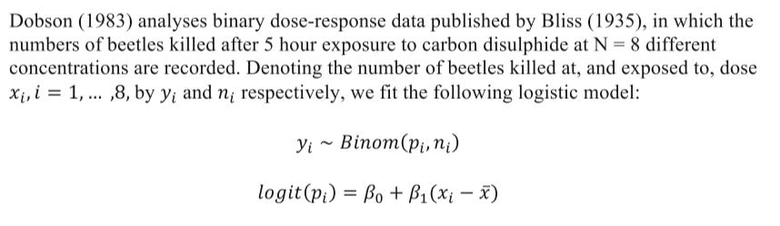

Task 2 Description

## 2.1 `a` Data

### 2.1.1 Data for Model

```r
dataList <- list(
                 # Dose exposed to the beetle
                 x = c(1.6907, 1.7242, 1.7552, 1.7842,
                       1.8113, 1.8369, 1.8610, 1.8839),

                 # Concentrations of carbon disulphide
                 n = c(59, 60, 62, 56, 63, 59, 62, 60),

                 # Number of beetles killed
                 y = c(6, 13, 18, 28, 52, 53, 61, 60)
                 )
```

### 2.1.2 Plots of data

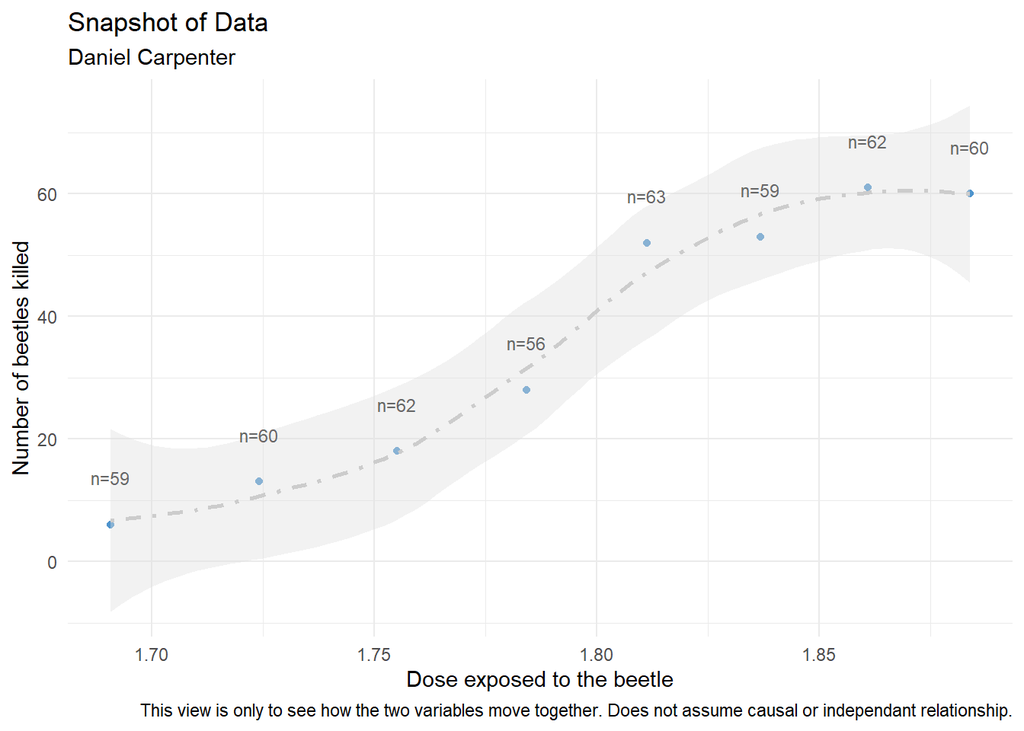

```r
require(tidyverse)
# Distance as a predictor
getGLMPlot(predictedValue = dataList$y, y = 'Number of beetles killed',
           predictor      = dataList$x, x = 'Dose exposed to the beetle',
           methodName = 'loess')  + # just using this to see the trend
  geom_text(aes(label = paste0('n=', dataList$n)),
                nudge_y = max(dataList$y) * 0.125,
            size = 3,
            color = 'grey40')
```

## 2.2 `b` JAGS Model `Logit` (*Centered*)

> Model centered Independant variable *dose* (`x`) around it’s mean  
> Uses a Logit Link
- To help convergence, *centering* causes nearly uncorrelated regression coeff’s
- [See reasoning for centering article](https://agabrioblog.onrender.com/tutorial/multiple-linear-regression-jags/multiple-linear-regression-jags/)

### 2.2.1 The JAGS Model for Beetles `Logit` (*Centered*)

```r
# The JAGS Model
modelName   = 'BeetlesLogitCenter'      # Name of the model for File Naming

modelStringLogitCenter =
"
model {

  for (i in 1:8) {

    # link and linear predictor
    y[i] ~ dbin(p[i], n[i])


    # In JAGS, ilogit is logistic. Use logistic since not 0/1 predicted values
    logit(p[i]) <- beta0 + ( beta1 * (x[i] - mean(x[])) ) # Note centering around mean

    phat[i] <- y[i]/n[i]
    yhat[i] <- n[i]*p[i]
  }

  # prior distributions
  beta0 ~ dnorm(  0.0, 0.001)
  beta1 ~ dnorm(  0.0, 0.001)
}
"
```

### 2.2.2 MCMC Model Control Inputs for Beetles `Logit` (*Centered*)

```r
# Model Name and Root
fileNameRoot= "Task 2 JAGS Output (Beetles)/" # Directory

## MCMC Controls
adaptSteps  = 500               # Number of steps to adapt the samplers
burnInSteps = 1000              # Number of steps to burn-in the chains
nChains     = 3                 # nChains should be 2 or more for diagnostics


## Parameter Definitions
parameters  = c("beta0",
                "beta1")
```

## 2.3 `c` Run Jags Model `Logit` (*Centered*)

```r
# Run the fun and store
codaSamplesLogitCenter <- runJagsFunction(modelStringLogitCenter,
                                          parameters =c("beta0", "beta1") ,
                                          nIter=5000, # Total iterations
                                          initsList   = list( beta0 = 0,  # Note initial values
                                                              beta1 = 0 )
                                          )
```

```
##
## Kruschke, J. K. (2015). Doing Bayesian Data Analysis, Second Edition:
## A Tutorial with R, JAGS, and Stan. Academic Press / Elsevier.
##
##
##
## Burning in the MCMC chain...
## Sampling final MCMC chain...
```

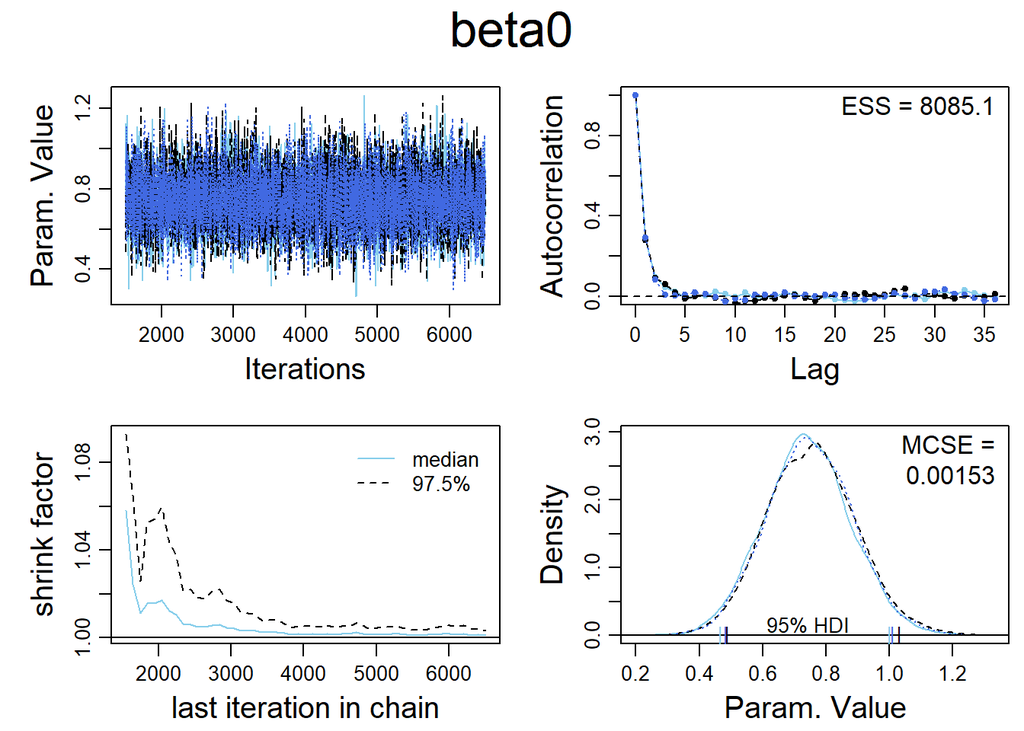

```r
# Diagnostics and Posteriors ----------------------------------------

# Beta 0
varName = paste0(parameters[1])
diagMCMC( codaObject=codaSamplesLogitCenter , parName=varName );
saveGraph( file=paste0(fileNameRoot,varName) , type="png" )
```

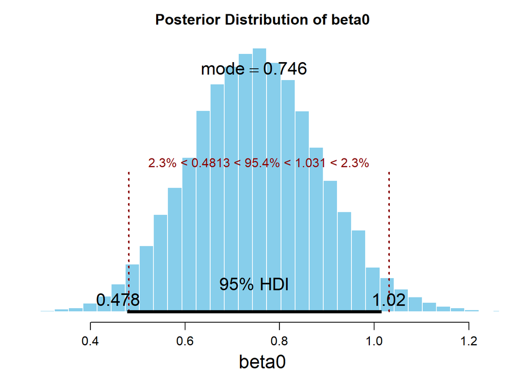

```
##            ESS      mean    median      mode hdiMass    hdiLow  hdiHigh compVal
## beta0 7933.613 0.7487704 0.7467885 0.7460674    0.95 0.4776911 1.015593      NA
##       pGtCompVal ROPElow ROPEhigh pLtROPE pInROPE pGtROPE
## beta0         NA  0.4813    1.031   0.023  0.9544  0.0226
```

```r
openGraph(); par( mar=c(3.5,0.5,2.5,0.5) , mgp=c(2.25,0.7,0) )
plotPost( codaSamplesLogitCenter[,varName] , main=paste0('Posterior Distribution of ', varName) , xlab=paste0(varName), ROPE = c(0.4813 , 1.031)) # from summary(codaSamplesLogitCenter)
```

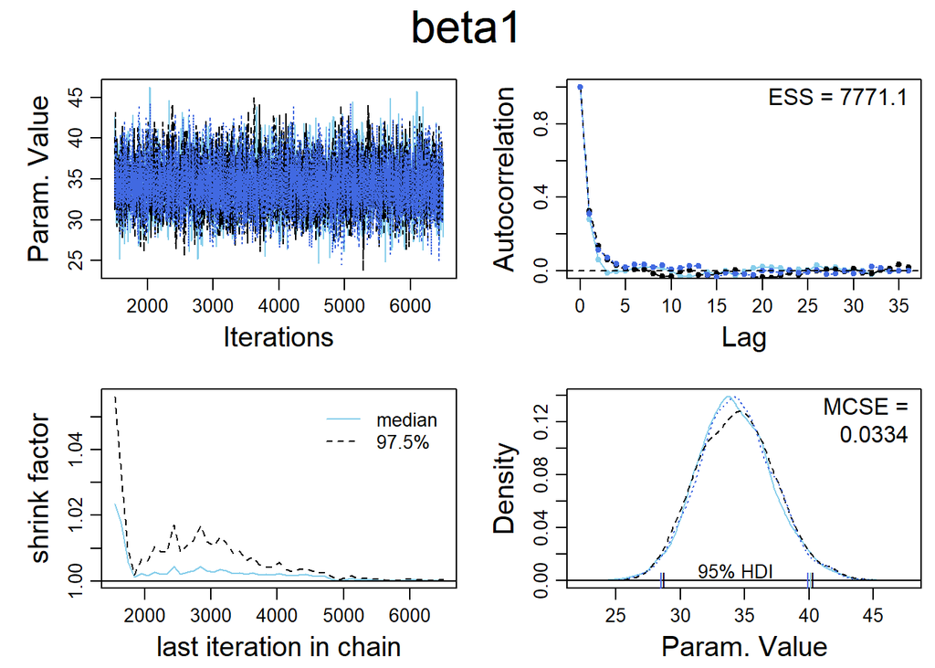

```r
# Beta 1
varName = paste0(parameters[2])
diagMCMC( codaObject=codaSamplesLogitCenter , parName=varName );
saveGraph( file=paste0(fileNameRoot,varName) , type="png" )
```

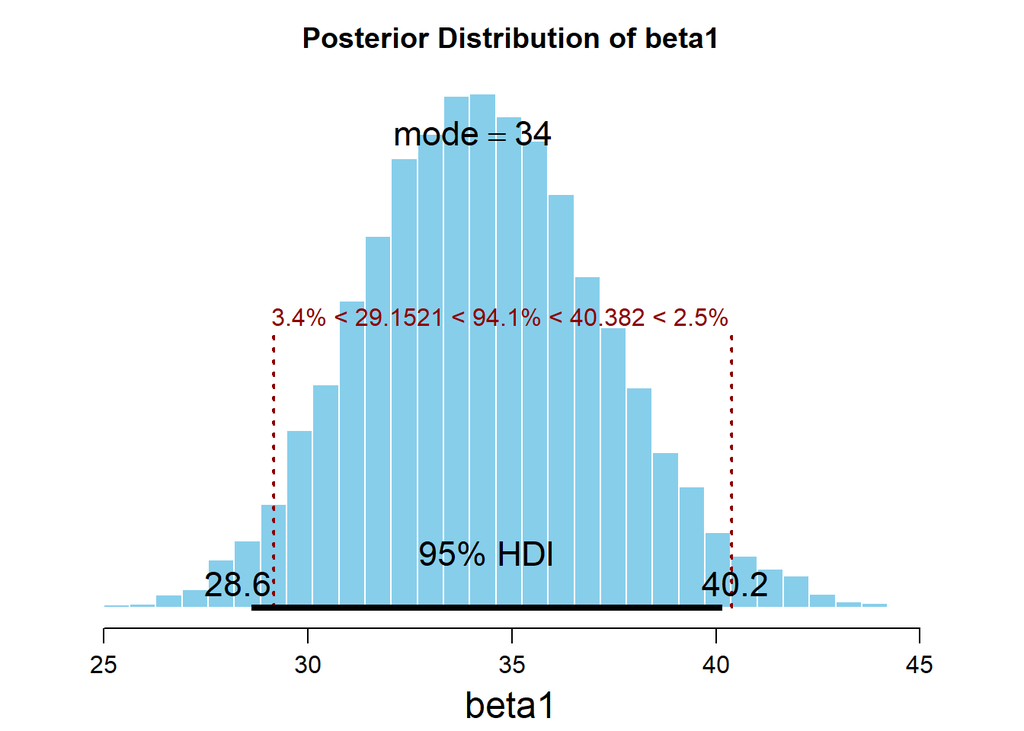

```
##            ESS     mean   median    mode hdiMass   hdiLow  hdiHigh compVal
## beta1 7760.687 34.32525 34.24753 34.0424    0.95 28.61579 40.15123      NA
##       pGtCompVal ROPElow ROPEhigh    pLtROPE   pInROPE    pGtROPE
## beta1         NA 29.1521   40.382 0.03393333 0.9411333 0.02493333
```

```r
openGraph(); par( mar=c(3.5,0.5,2.5,0.5) , mgp=c(2.25,0.7,0) )
plotPost( codaSamplesLogitCenter[,varName] , main=paste0('Posterior Distribution of ', varName) , xlab=paste0(varName), ROPE = c(29.1521  , 40.382)) # from summary(codaSamplesLogitCenter)
```

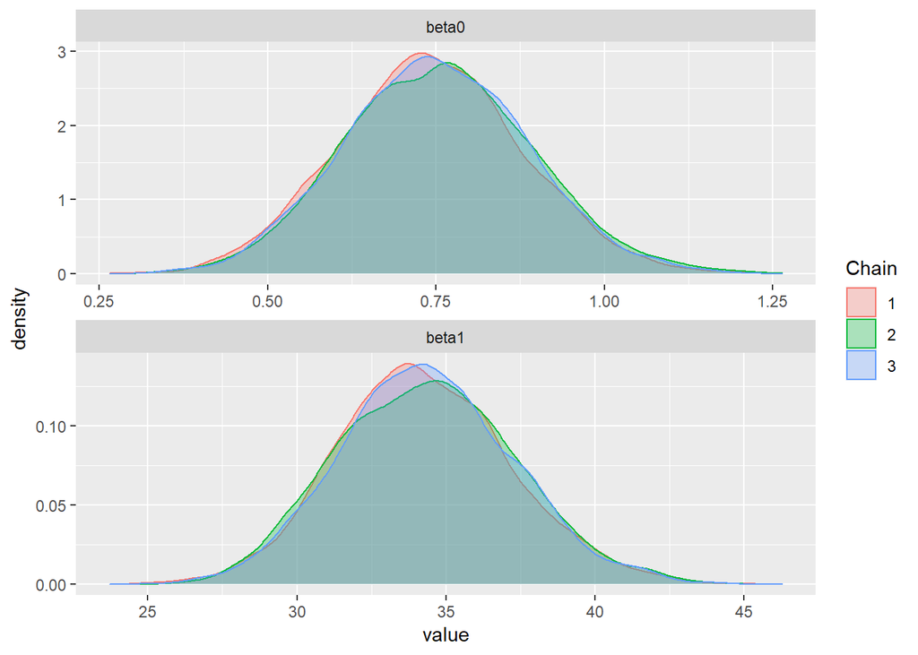

```r
# graphics.off()

# Density Plots
library(ggmcmc)
s = ggs(codaSamplesLogitCenter)
d = ggs_density(s)
print(d)
```

```r
# Using Baysian Methods
summary(codaSamplesLogitCenter)
```

```
##
## Iterations = 1501:6500
## Thinning interval = 1
## Number of chains = 3
## Sample size per chain = 5000
##
## 1. Empirical mean and standard deviation for each variable,
##    plus standard error of the mean:
##
##          Mean     SD Naive SE Time-series SE
## beta0  0.7488 0.1377 0.001124       0.001532
## beta1 34.3253 2.9458 0.024052       0.033677
##
## 2. Quantiles for each variable:
##
##         2.5%     25%     50%     75%  97.5%
## beta0  0.486  0.6545  0.7468  0.8398  1.025
## beta1 28.798 32.2822 34.2475 36.2726 40.371
```

## 2.4 `d` *Non-Centered* Independant Var

### 2.4.1 JAGS Model (Non-Centered)

> Model does *not* centered Independant variable `dose`  
> See reasoning for centering on mean above

### 2.4.2 The JAGS Model for Beetles (*not centered*)

```r
# The JAGS Model
modelName   = 'BeetlesLogitNonCenter'      # Name of the model for File Naming
modelString =
"
model {

  for (i in 1:8) {

    # link and linear predictor
    y[i] ~ dbin(p[i], n[i])


    # In JAGS, ilogit is logistic. Use logistic since not 0/1 predicted values
    # Note that x is non-centered now since it is not centering around mean
    logit(p[i]) <- beta0 + ( beta1 * x[i] )      # Removed (x[i] - mean(x[]))

    phat[i] <- y[i]/n[i]
    yhat[i] <- n[i]*p[i]
  }

  # prior distributions
  beta0 ~ dnorm(  0.0, 0.001)
  beta1 ~ dnorm(  0.0, 0.001)
}
"
```

### 2.4.3 Run Jags Model (*Non-Centered*)

- Note inputs same as last model except for `modelString` changed directly above

```r
# Run the fun and store
codaSamplesLogitNonCenter <- runJagsFunction(modelString, parameters = c("beta0",
                                                                         "beta1"),
                                             nIter=5000, # Total iterations
                                             initsList   = list( beta0 = 1,
                                                                 beta1 = 1 )
                                             )
```

```
##
## Kruschke, J. K. (2015). Doing Bayesian Data Analysis, Second Edition:
## A Tutorial with R, JAGS, and Stan. Academic Press / Elsevier.
##
##
##
## Burning in the MCMC chain...
## Sampling final MCMC chain...
```

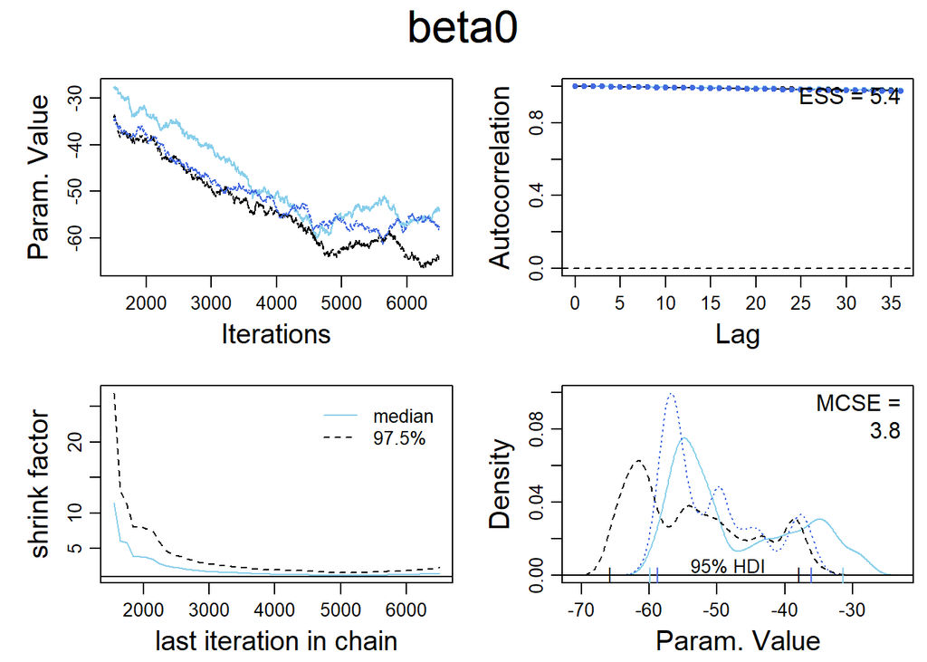

```r
# Diagnostics and Posteriors ----------------------------------------

# Beta 0
varName = paste0(parameters[1])
diagMCMC( codaObject=codaSamplesLogitNonCenter , parName=varName );
saveGraph( file=paste0(fileNameRoot,varName) , type="png" )
```

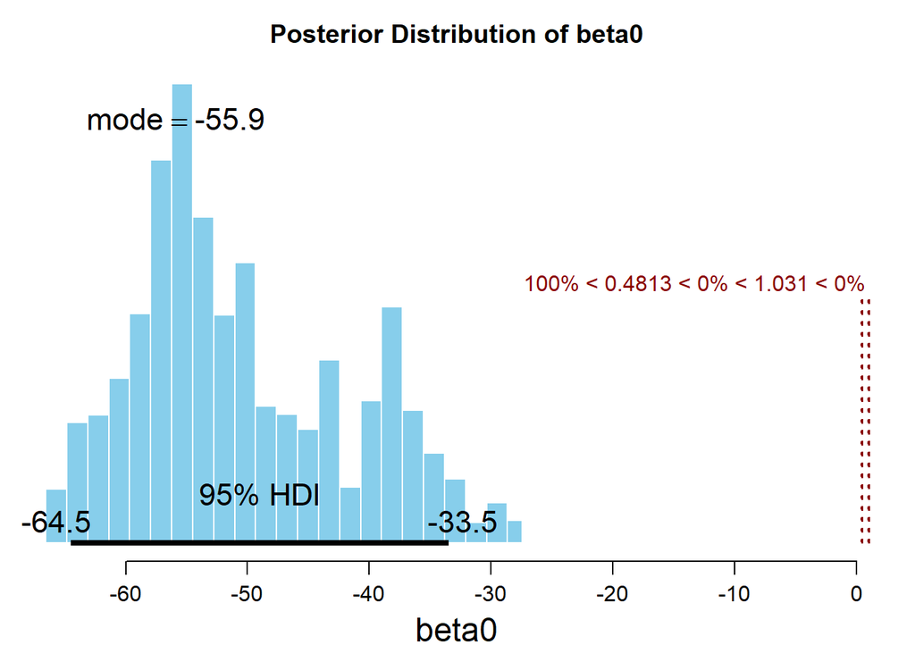

```
##            ESS      mean    median      mode hdiMass    hdiLow   hdiHigh
## beta0 6.704779 -50.46672 -52.77049 -55.88215    0.95 -64.50721 -33.47138
##       compVal pGtCompVal ROPElow ROPEhigh pLtROPE pInROPE pGtROPE
## beta0      NA         NA  0.4813    1.031       1       0       0
```

```r
openGraph(); par( mar=c(3.5,0.5,2.5,0.5) , mgp=c(2.25,0.7,0) )
plotPost( codaSamplesLogitNonCenter[,varName] , main=paste0('Posterior Distribution of ', varName) , xlab=paste0(varName), ROPE = c(0.4813 , 1.031)) # from summary(codaSamplesLogitNonCenter)
```

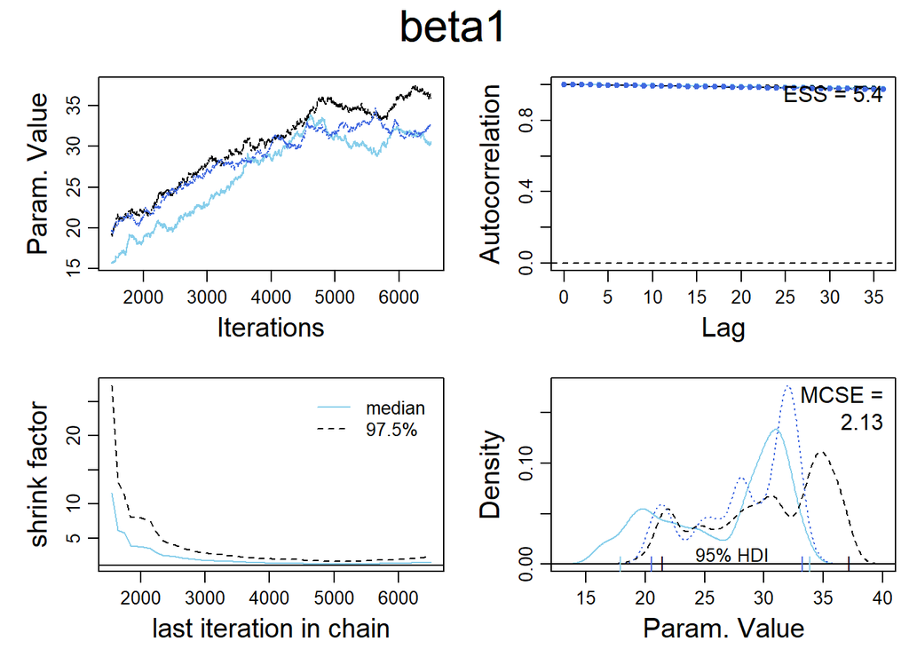

```r
# Beta 1
varName = paste0(parameters[2])
diagMCMC( codaObject=codaSamplesLogitNonCenter , parName=varName );
saveGraph( file=paste0(fileNameRoot,varName) , type="png" )
```

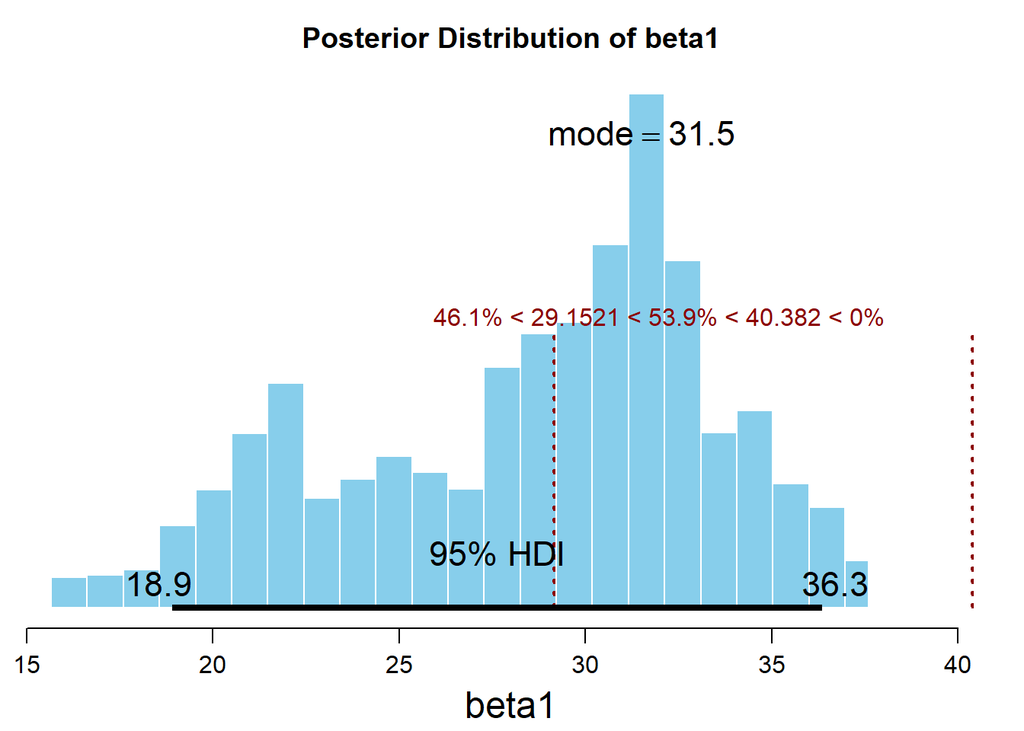

```
##            ESS     mean   median     mode hdiMass   hdiLow  hdiHigh compVal
## beta1 6.697266 28.51482 29.79323 31.50916    0.95 18.91536 36.34678      NA
##       pGtCompVal ROPElow ROPEhigh   pLtROPE   pInROPE pGtROPE
## beta1         NA 29.1521   40.382 0.4612667 0.5387333       0
```

```r
openGraph(); par( mar=c(3.5,0.5,2.5,0.5) , mgp=c(2.25,0.7,0) )
plotPost( codaSamplesLogitNonCenter[,varName] , main=paste0('Posterior Distribution of ', varName) , xlab=paste0(varName), ROPE = c(29.1521  , 40.382)) # from summary(codaSamplesLogitNonCenter)
```

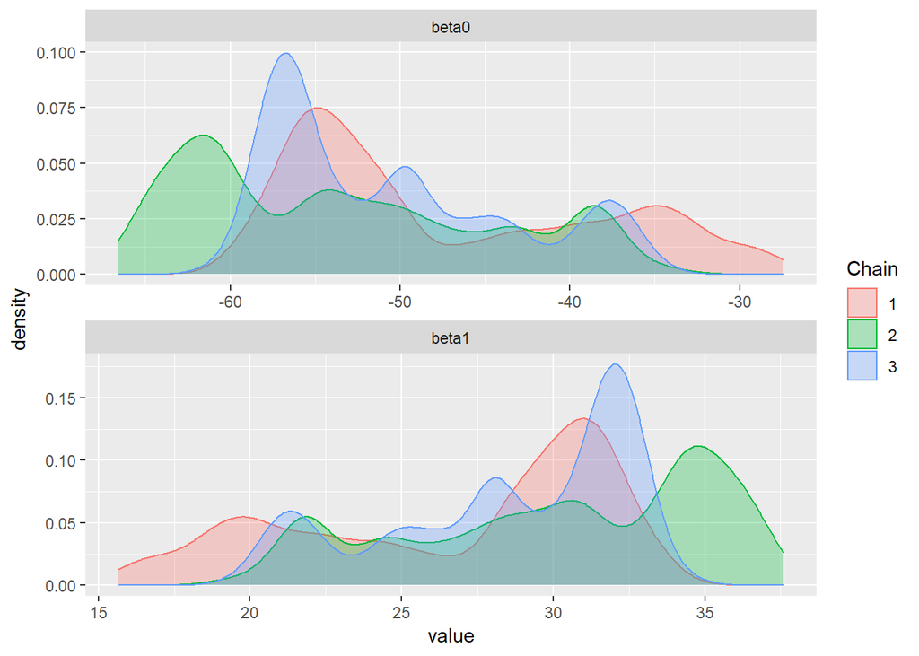

```r
# graphics.off()

# Density Plots
library(ggmcmc)
s = ggs(codaSamplesLogitNonCenter)
d = ggs_density(s)
print(d)
```

```r
# Using Baysian Methods
summary(codaSamplesLogitNonCenter)
```

```
##
## Iterations = 1501:6500
## Thinning interval = 1
## Number of chains = 3
## Sample size per chain = 5000
##
## 1. Empirical mean and standard deviation for each variable,
##    plus standard error of the mean:
##
##         Mean    SD Naive SE Time-series SE
## beta0 -50.47 8.794  0.07181          3.676
## beta1  28.51 4.938  0.04032          2.059
##
## 2. Quantiles for each variable:
##
##         2.5%    25%    50%    75%  97.5%
## beta0 -64.20 -56.80 -52.77 -43.57 -32.63
## beta1  18.51  24.63  29.79  32.07  36.22
```

## 2.5 `e` Interpretation (*Non-Centered*)

- Parameter values never hover around the mean
- High Autocorrelation occurs and never reduces.
- Shrink factor unstable and never settles
- Clearly, the model does not converge among the three chains.

## 2.6 `f` Pairs Plots

> Centered vs. Non-Centered Independant Variables

### 2.6.1 Create the Plots

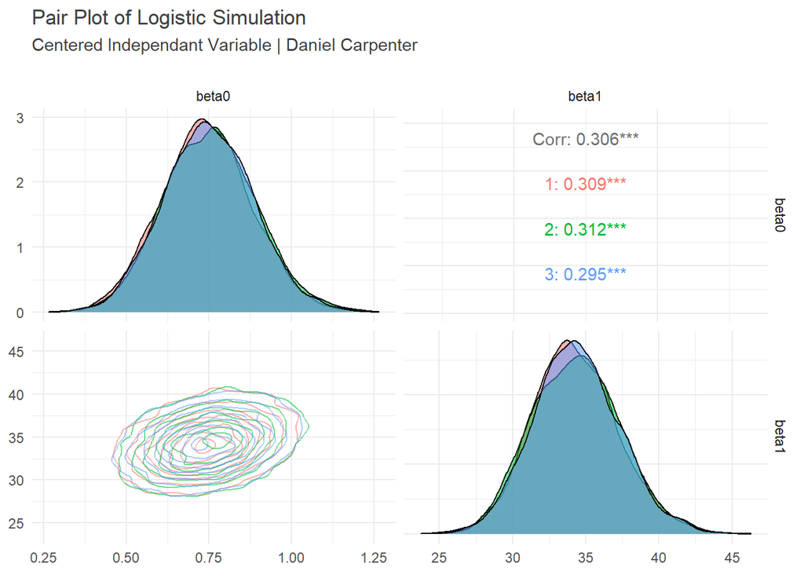

```r
require(ggmcmc)
library(GGally)

# Centered Independant Variable
ggs_pairs(ggs(codaSamplesLogitCenter),

          # Change to Contours
          lower = list(continuous =  'density'),

          # Color by Chain and add transparency
          mapping = aes(color = Chain, alpha = 0.2)
          ) +
  labs(title = 'Pair Plot of Logistic Simulation',
       subtitle = 'Centered Independant Variable | Daniel Carpenter\n') +
  theme_minimal() + theme(text = element_text(color = 'grey25'))
```

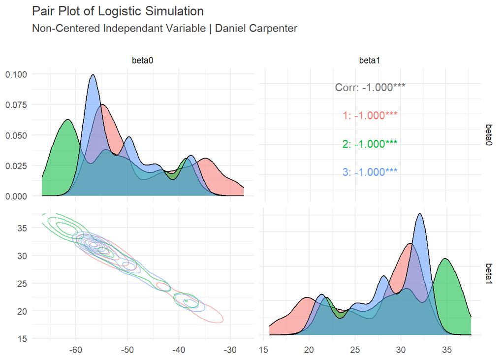

```r
# Centered Independent Variable
ggs_pairs(ggs(codaSamplesLogitNonCenter),

          # Change to Contours
          lower = list(continuous =  'density'),

          # Color by Chain and add transparency
          mapping = aes(color = Chain, alpha = 0.2)
          ) +
  labs(title = 'Pair Plot of Logistic Simulation',
       subtitle = 'Non-Centered Independant Variable | Daniel Carpenter\n') +
  theme_minimal() + theme(text = element_text(color = 'grey25'))
```

### 2.6.2 Pairs - Centering/Non-Centering

#### 2.6.2.1 *Centering* accomplishes…

- Centering allows for convergence among the chains
- Low levels of cross-correlation
- Extremely stable results

## 2.7 `g` Random vs. Non-Random Vars

[output not shown]

## 2.8 `h` Jags Model using `Probit` (*Centered*)

### 2.8.1 The JAGS Model for `Probit` Beetles

```r
# The JAGS Model
modelName   = 'BeetlesProbitNonCenter'      # Name of the model for File Naming

modelString =
"
model {

  for (i in 1:8) {

    # link and linear predictor
    y[i] ~ dbin(p[i], n[i])

    # Now using a probit
    probit(p[i]) <- beta0 + ( beta1 * (x[i] - mean(x[])) ) # Note centering around mean

    # Note The old logit method
    # logit(p[i]) <- beta0 + ( beta1 * (x[i] - mean(x[])) ) # Note centering around mean

    phat[i] <- y[i]/n[i]
    yhat[i] <- n[i]*p[i]
  }

  # prior distributions
  beta0 ~ dnorm(  0.0, 0.001)
  beta1 ~ dnorm(  0.0, 0.001)
}
"
```